# Book displays recommendation for Flourish and Blotts Bookshop

Raju Penmetcha

2017-04-11

# Overview

There are many types of bookshop customers, ranging from the casual browser, the student looking for a specific course text book, book club members looking for their reading list, and seasonal book readers based on trends. They are all different but they have one thing in common; if their eyes are drawn to an outstanding display with popular and high moving books they will stop and look and buy. It is critical to book shop like Flourish and Blotts to understand customer preferences, frequently read books and other similar books they likely would purchase. This provides bookshop managers to place display cases strategically to increase sales and profitability to the bookshop.

Following analysis uses Frequent Pattern Analysis (FPA) analysis to provide recommendation to store manger at Flourish and Blotts.

# R Packages

The packages you will need to install for the week are **Matrix**, **arules** and **arulesViz**.

# Purpose for the analysis

The manager of **Flourish and Blotts** bookstore is trying to decide the best ways to arrange the book displays for the upcoming summer season in order to increase sales.

The requirement is to analyze *90,000 plus* historical sales transactions and identify following recommendation for the book store.

- **What are the bestselling book titles at Flourish and Blotts.**
- **What book title should be displayed strategically to increase sales to book club members like Oprah’s book club.**
- **Recommend other book titles to display on the book cases that are appealing to the customers and would increase sales at the store, in this recommendation exclude “Girls with the Dragon Tattoo” and “Wild Animus” title series.**

# Frequent Pattern Analysis (Association Rule Mining)

Applications of FPA include analyses of market basket, DNA sequence, click stream analysis, and marketing activities (sale campaign; cross-marketing; etc.). We are going to examine two FPA algorithms: **Apriori** and **ECLAT**. **Apriori** is the more popular algorithm, but it can take up a lot of computational resources. **ECLAT** is a more efficient algorithm (i.e. faster) on smaller datasets.

FPA provides results in a set of association rules. A typical association rule would state that given itemset X, then itemset Y is likely to occur. For example, {diaper} -> {beer}. Customers who purchase diapers are likely to purchase beer.

Association rules are determined based on two quality measures: **support** and **confidence**.

```
Support: How often does the rule happen?
```

```
Confidence: How often is the rule correct?
```

Agrawal, Imielinski, and Swami (1993) said confidence is the “rule’s strength.”

Confidence is calculated as follows:

```
confidence(X->Y)=(support(X,Y))/(support(X))
```

# The Dataset

The *Flourish and Blotts* dataset contains *92,108* transactions containing *220,447* items(books) purchased at the store.

Load transaction dataset into workspace for analysis

```r
getwd()
```

```
## [1] "C:/Users/Jupiter/Downloads/RU/BIA6301ADM/Homework/submission/week4/ADM_Wekk4_Project/script"
```

```r
setwd("C:/Users/Jupiter/Downloads/RU/BIA6301ADM/Homework/submission/week4/ADM_Wekk4_Project/data")

library(Matrix)
library(arules)
bookbaskets <- read.transactions("bookdata.tsv.gz", format="single",    # Note: 2
                                 sep="\t",                      # Note: 3
                                 cols=c("userid", "title"),     # Note: 4
                                 rm.duplicates=T)           # Note: 5
```

```
## distribution of transactions with duplicates:
## items
##   1   2   3   4   5   6   7   8   9  10  11  12  13  14  15  16  17  18
## 701 222 106  68  43  39  23  24  18  18  16  10   7   7  13   7   8   5
##  19  20  21  22  23  25  26  27  28  29  30  31  33  34  35  38  39  42
##   3   9   4   4   3   2   2   5   4   5   4   4   1   2   1   1   1   2
##  44  45  47  48  49  52  56  57  59  61  63  71  73  80  84  86  91  93
##   1   1   1   1   1   1   2   1   2   1   2   1   1   1   1   1   1   1
##  95  96  99 103 158 206 260 891
##   1   1   1   1   1   2   1   1
```

# Exploratory Data Analysis

Explore the dataset structure and item aggregate details to understand the frequently occurring book titles, etc.

```r
# Summary of the dataset
summary(bookbaskets)
```

```
## transactions as itemMatrix in sparse format with
##  92108 rows (elements/itemsets/transactions) and
##  220447 columns (items) and a density of 5.034811e-05
##
## most frequent items:
##                           Wild Animus
##                                  2502
##             The Lovely Bones: A Novel
##                                  1295
##                     She's Come Undone
##                                   934
##                     The Da Vinci Code
##                                   905
## Harry Potter and the Sorcerer's Stone
##                                   832
```

[output cut: 132 more lines]

```r
# Examine the first five transactions
inspect(bookbaskets[1:5])
```

```
##     items                                                                                           transactionID
## [1] {New Vegetarian: Bold and Beautiful Recipes for Every Occasion}                                        10
## [2] {Il Dio Delle Piccole Cose}                                                                            1000
## [3] {Cybernation}                                                                                          100001
## [4] {Lasher: Lives of the Mayfair Witches}                                                                 100002
## [5] {Chicken Soup for the Teenage Soul on Tough Stuff : Stories of Tough Times and Lessons Learned,
##      Dragon Ball Z, Vol. 1,
##      Harry Potter and the Chamber of Secrets,
##      Harry Potter and the Sorcerer's Stone,
##      Holes,
##      Prey,
##      Primary Colors: A Novel of Politics,
##      Rising Sun,
##      The Cat Who Smelled a Rat,
##      The Fellowship of the Ring,
##      The Hunt for Red October,
##      The Return of the King,
##      The Two Towers}                                                                                       100004
```

```r
# Calculate number of books purchased by "userID"
basketSizes<-size(bookbaskets)
View(basketSizes[1:20])

# Calculate the support for each book title or frequently purchased book
bookFreq_relative <-itemFrequency(bookbaskets, type = "relative" )
View(bookFreq_relative[1:10])

 # Get the absolute count of book occurrences.
bookFreq_absolute <-itemFrequency(bookbaskets, type = "absolute" )
#bookFreq_absolute <- (bookFreq/sum(bookFreq))*sum(basketSizes)
View(bookFreq_absolute[1:10])
str(bookFreq_absolute)
```

```
##  Named int [1:220447] 2 1 1 3 3 1 1 26 1 1 ...
##  - attr(*, "names")= chr [1:220447] "''N'' Is for Noose" "' Allo 'Allo: the War Diaries of Rene Artois" "' Boule De Suif" "' Civil Disobedience' and 'Reading'" ...
```

```r
bookFreq_absolute_tbl <- table(bookFreq_absolute)
bookFreq_absolute_tbl
```

```
## bookFreq_absolute
##      1      2      3      4      5      6      7      8      9     10
## 114738  38630  18514  10501   6999   4978   3703   2712   2191   1804
##     11     12     13     14     15     16     17     18     19     20
##   1493   1244   1087    947    755    662    631    538    439    393
##     21     22     23     24     25     26     27     28     29     30
##    407    347    358    260    285    268    206    216    208    228
##     31     32     33     34     35     36     37     38     39     40
##    172    174    147    151    132    129    130    104    105    102
##     41     42     43     44     45     46     47     48     49     50
##    101     89     94     76     87     83     67     71     68     57
##     51     52     53     54     55     56     57     58     59     60
##     53     62     49     57     68     49     45     46     49     36
##     61     62     63     64     65     66     67     68     69     70
##     47     38     42     45     29     24     38     27     33     21
```

[output cut: 66 more lines]

```r
str(bookFreq_absolute_tbl)
```

```
##  'table' int [1:397(1d)] 114738 38630 18514 10501 6999 4978 3703 2712 2191 1804 ...
##  - attr(*, "dimnames")=List of 1
##   ..$ bookFreq_absolute: chr [1:397] "1" "2" "3" "4" ...
```

```r
#Only keep transactions with more than one book purchased.
bookbasket_gt1 <- bookbaskets[basketSizes>1]

bookbasket_gt1[1:10]
```

```
## transactions in sparse format with
##  10 transactions (rows) and
##  220447 items (columns)
```

```r
summary(bookbasket_gt1)
```

```
## transactions as itemMatrix in sparse format with
##  40822 rows (elements/itemsets/transactions) and
##  220447 columns (items) and a density of 0.0001079031
##
## most frequent items:
##                           Wild Animus
##                                  1981
##             The Lovely Bones: A Novel
##                                  1123
##                     She's Come Undone
##                                   847
##                     The Da Vinci Code
##                                   822
## Harry Potter and the Sorcerer's Stone
##                                   768
```

[output cut: 132 more lines]

```r
####
```

## Visualizing the bookbasket data with frequently purchased book titles

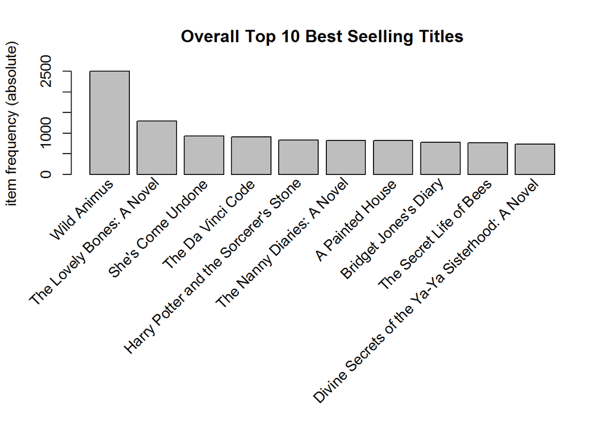

```r
itemFrequencyPlot(bookbaskets, topN = 10, type = "absolute", main = "Overall Top 10 Best Seelling Titles")
```

## Best Selling Book Results:

### Based on whole transaction population the bestselling or very frequently purchased titles are:

1. Wild Animus
2. The Lovely Bones: A Novel
3. She’s Come Undone
4. The Da Vinci Code
5. Harry Potter and the Sorcerer’s Stone
6. The Nanny Diaries: A Novel
7. A Painted House
8. Bridget Jones’s Diary
9. The Secret Life of Bees 10.Divine Secrets of the Ya-Ya Sisterhood: A Novel

These results are based on book titles purchases made frequently across the population plotted using the above graph of top 10 titles.

# Analyze and recommend titles to display on cases for book club members’ preference

### since typical book club members are who is reading titles featured by Oprah book club, following steps would extract Oprah’s book list titles from the website http://www.oprah.com/app/books.html.

[figure not shown]

- Extracted Oprah book club book list (72 count) from the website as csv file. Data contains book title and author name.
- Removed non-relevant items(columns) from the dataset.
- Following steps will load the Oprah book club list into workspace for analysis.

```r
library(readr)

Oprah_booklist <- read_csv("C:/Users/Jupiter/Downloads/RU/BIA6301ADM/Homework/submission/week4/ADM_Wekk4_Project/data/Oprah_bookshelf_list.csv")
#View(Oprah_booklist)
#typeof(Oprah_booklist)

#rm(Oprah_booktitles)
Oprah_booktitles <- Oprah_booklist$title
#typeof(Oprah_booklist_title)
Oprah_booktitles[1:10]
```

```
##  [1] "The Invention of Wings about"
##  [2] "Wild: From Lost to Found on the Pacific Crest Trail"
##  [3] "A Tale of Two Cities / Great Expectations"
##  [4] "Freedom"
##  [5] "Say You're One of Them"
##  [6] "The Story of Edgar Sawtelle"
##  [7] "A New Earth"
##  [8] "The Pillars of the Earth (The Pillars of the Earth, #1)"
##  [9] "Love in the Time of Cholera"
## [10] "Middlesex"
```

Some of the bookclub titles extracted from the website are not in the bookbasket population, therefore, removed not found book titles from the Oprah bookclub list for better comparison and analysis.

```r
rm(Oprah_booktitles_sel)
Oprah_booktitles_sel <- list()

j <- 1

for(i in 1:72) {
       tryCatch(
                {
                    which(bookbasket_gt1 %in% c(Oprah_booktitles[c(i)]))

                    Oprah_booktitles_sel[j] <-  Oprah_booktitles[c(i)]

                    j <- j + 1},


                error = function(e) {print(paste("Error Not Found - ", Oprah_booktitles[c(i)]));
                                      }
                  )
}
```

```
## [1] "Error Not Found -  The Invention of Wings about"
## [1] "Error Not Found -  Wild: From Lost to Found on the Pacific Crest Trail"
## [1] "Error Not Found -  A Tale of Two Cities / Great Expectations"
## [1] "Error Not Found -  Say You're One of Them"
## [1] "Error Not Found -  The Story of Edgar Sawtelle"
## [1] "Error Not Found -  A New Earth"
## [1] "Error Not Found -  The Pillars of the Earth (The Pillars of the Earth, #1)"
## [1] "Error Not Found -  The Road"
## [1] "Error Not Found -  The Measure of a Man: A Spiritual Autobiography"
## [1] "Error Not Found -  The Twelve Tribes of Hattie"
## [1] "Error Not Found -  Light in August"
## [1] "Error Not Found -  The Sound and the Fury"
## [1] "Error Not Found -  The Heart Is a Lonely Hunter"
## [1] "Error Not Found -  Cry, The Beloved Country"
## [1] "Error Not Found -  Icy Sparks (Oprah's Book Club)"
## [1] "Error Not Found -  Pilot's Wife"
## [1] "Error Not Found -  Where the Heart Is"
## [1] "Error Not Found -  What Looks Like Crazy on an Ordinary Day (Idlewild #1)"
## [1] "Error Not Found -  Here on Earth"
## [1] "Error Not Found -  The Treasure Hunt: A Little Bill Book"
## [1] "Error Not Found -  The Meanest Thing To Say"
## [1] "Error Not Found -  Stones from the River"
## [1] "Error Not Found -  The Deep End of the Ocean (Cappadora Family, #1)"
```

```r
Oprah_booktitles_sel
```

```
## [[1]]
## [1] "Freedom"
##
## [[2]]
## [1] "Love in the Time of Cholera"
##
## [[3]]
## [1] "Middlesex"
##
## [[4]]
## [1] "Night"
##
## [[5]]
## [1] "A Million Little Pieces"
##
## [[6]]
## [1] "As I Lay Dying"
##
## [[7]]
## [1] "The Good Earth"
##
## [[8]]
## [1] "Anna Karenina"
##
## [[9]]
## [1] "One Hundred Years of Solitude"
##
## [[10]]
## [1] "East of Eden"
##
## [[11]]
## [1] "Sula"
##
## [[12]]
## [1] "Fall on Your Knees"
##
## [[13]]
## [1] "A Fine Balance"
##
## [[14]]
```

[output cut: 91 more lines]

```
##
## [[45]]
## [1] "The Heart of a Woman"
##
## [[46]]
## [1] "The Rapture of Canaan"
##
## [[47]]
## [1] "She's Come Undone"
##
## [[48]]
## [1] "The Book of Ruth"
##
## [[49]]
## [1] "Song of Solomon"
```

### Run apriori for the selected bookclub titles and inspect top 20 likely books purchased by customers

### Using following parameter settings for bookclub rules

support = 0.001 (or .10%) confidence = 0.10 (or 10%) maxlen = maximum number of items in a rule. Default is 10. minlen = minimum number of items in a rule. Default is 1.

Used Appearance argument of the apriori to restrict on the associations mined by apriori.

```r
rm(bookclubrules)
bookclubrules <- apriori(bookbaskets, parameter = list(support =
                          0.001, confidence = 0.10, minlen = 1),
                          appearance = list(both = c(Oprah_booktitles_sel),
                                            default="lhs"))
```

```
## Apriori
##
## Parameter specification:
##  confidence minval smax arem  aval originalSupport maxtime support minlen
##         0.1    0.1    1 none FALSE            TRUE       5   0.001      1
##  maxlen target   ext
##      10  rules FALSE
##
## Algorithmic control:
##  filter tree heap memopt load sort verbose
##     0.1 TRUE TRUE  FALSE TRUE    2    TRUE
##
## Absolute minimum support count: 92
##
## set item appearances ...[49 item(s)] done [0.00s].
## set transactions ...[220447 item(s), 92108 transaction(s)] done [0.33s].
## sorting and recoding items ... [1128 item(s)] done [0.03s].
## creating transaction tree ... done [0.02s].
## checking subsets of size 1 2 3 4 5 done [0.02s].
## writing ... [84 rule(s)] done [0.00s].
## creating S4 object  ... done [0.02s].
```

### Let’s look at “Lift” for book title recommendations.

In the context of our current analysis, lift measures “how much more likely an item is to be purchased relative to its typical purchase rate, given that you know another item has been purchased” (Lantz 2013, p. 261).

For example:

[output not shown]

## Improving Performance

Let’s sort the rules by lift.

```r
inspect(head(sort(bookclubrules, by = "lift"),20))
```

```
##      lhs                             rhs
## [1]  {The Pilot's Wife : A Novel} => {Jewel}
## [2]  {Where The Heart Is}         => {Jewel}
## [3]  {Midwives: A Novel}          => {House of Sand and Fog}
## [4]  {The Pilot's Wife : A Novel} => {While I Was Gone}
## [5]  {Where The Heart Is}         => {While I Was Gone}
## [6]  {The Pilot's Wife : A Novel} => {The Reader}
## [7]  {Vinegar Hill}               => {She's Come Undone}
## [8]  {She's Come Undone}          => {Vinegar Hill}
## [9]  {I Know This Much Is True}   => {She's Come Undone}
## [10] {She's Come Undone}          => {I Know This Much Is True}
## [11] {The Deep End of the Ocean}  => {She's Come Undone}
## [12] {She's Come Undone}          => {We Were the Mulvaneys}
## [13] {We Were the Mulvaneys}      => {She's Come Undone}
## [14] {Jewel}                      => {She's Come Undone}
```

[output cut: 27 more lines]

## Book Club Results:

### Based on above analysis placing following book titles on book club related book cases in the store would appeal to the book club members and improve sales to those customers. This can be replicated to other book club lists to place titles on the cases for targeted sales increase at the store.

The following selected book titles should be displayed together at book club members display area, this list is derived based on the Oprah’s book club recommended list.

For example lhs rhs support confidence lift  
[1] {The Pilot’s Wife : A Novel} => {Jewel} 0.001053112 0.1707746 46.53761

a suppport value of 0.001 for this rule means the “The Pilot’s wife: Anovel” book appeared 0.1% of the bookbasket. A confidance of 0.17 for this rule implies that when “The Pilot’s….” book was purchased 17% of the time “Jewel” book is also purchased. The lift of 46 measures “how much more likely an item is to be purchased relative to its typical purchase rate.

- The Pilot’s Wife : A Novel
- Jewel
- Where The Heart Is
- Midwives: A Novel
- House of Sand and Fog
- While I Was Gone
- The Reader
- Vinegar Hill
- She’s Come Undone
- I Know This Much Is True
- The Deep End of the Ocean
- We Were the Mulvaneys
- Here On Earth
- The Book of Ruth
- Drowning Ruth

# Eximine and recommend other books (non bookclub list) to be placed on the cases for genric customers.

As per the book store manager requirements analysis should exclude *Girl with the Dragon Tattoo* and *Wild Animus* book series from the general recommendation.

### Exclude book list “The Girl with the Dragon Tattoo” series ref:https://en.wikipedia.org/wiki/Millennium_(novel_series)

- The Girl with the Dragon Tattoo
- The Girl Who Played with Fire
- The Girl Who Kicked the Hornets’ Nest
- The Girl in the Spider’s Web

### Exclude “Wild Animus” series.

### Exclude Oprah’s book club list that is already used and provided recommendation above

- Oprah_booktitles_sel

### Combine all three exclusion into one list object

```r
# list
#book_exclude <- list("The Girl with the Dragon Tattoo",
#                     "The Girl Who Played with Fire",
#                     "The Girl Who Kicked the Hornets' Nest",
#                     "The Girl in the Spider's Web",
#                     "Wild Animus")
# The Girl with the Dragon Tattoo series book doesn not exist in the population
book_exclude <- list("Wild Animus")



book_exclude_all <- append(book_exclude, Oprah_booktitles_sel)


book_exclude_all
```

```
## [[1]]
## [1] "Wild Animus"
##
## [[2]]
## [1] "Freedom"
##
## [[3]]
## [1] "Love in the Time of Cholera"
##
## [[4]]
## [1] "Middlesex"
##
## [[5]]
## [1] "Night"
##
## [[6]]
## [1] "A Million Little Pieces"
##
## [[7]]
## [1] "As I Lay Dying"
##
## [[8]]
## [1] "The Good Earth"
##
## [[9]]
## [1] "Anna Karenina"
##
## [[10]]
## [1] "One Hundred Years of Solitude"
##
## [[11]]
## [1] "East of Eden"
##
## [[12]]
## [1] "Sula"
##
## [[13]]
## [1] "Fall on Your Knees"
##
## [[14]]
```

[output cut: 94 more lines]

```
##
## [[46]]
## [1] "The Heart of a Woman"
##
## [[47]]
## [1] "The Rapture of Canaan"
##
## [[48]]
## [1] "She's Come Undone"
##
## [[49]]
## [1] "The Book of Ruth"
##
## [[50]]
## [1] "Song of Solomon"
```

### Using default parameter settings

support = 0.1 (or 10%) confidence = 0.8 (or 80%) maxlen = maximum number of items in a rule. Default is 10. minlen = minimum number of items in a rule. Default is 1.

Let’s try the default parameter settings first.

```r
apriori(bookbaskets)
```

```
## Apriori
##
## Parameter specification:
##  confidence minval smax arem  aval originalSupport maxtime support minlen
##         0.8    0.1    1 none FALSE            TRUE       5     0.1      1
##  maxlen target   ext
##      10  rules FALSE
##
## Algorithmic control:
##  filter tree heap memopt load sort verbose
##     0.1 TRUE TRUE  FALSE TRUE    2    TRUE
##
## Absolute minimum support count: 9210
##
## set item appearances ...[0 item(s)] done [0.00s].
## set transactions ...[220447 item(s), 92108 transaction(s)] done [0.35s].
## sorting and recoding items ... [0 item(s)] done [0.02s].
## creating transaction tree ... done [0.00s].
## checking subsets of size 1 done [0.00s].
## writing ... [0 rule(s)] done [0.00s].
## creating S4 object  ... done [0.02s].
```

```
## set of 0 rules
```

No rules were found with default settings. We will try again with some tweakings to the parameter settings.

### Other books analysis 1: Using following parameter settings

support = 0.002 (or .2%) confidence = 0.5 (or 50%) maxlen = maximum number of items in a rule. Default is 10. minlen = minimum number of items in a rule. Default is 1. appearance with exclude book list

```r
#rm(bookotherrules)
bookotherrules <- apriori(bookbaskets, parameter = list(support =
                          0.002, confidence = 0.5, minlen = 1),
                          appearance = list(none = c(book_exclude_all),
                                            default="both")
                          )
```

```
## Apriori
##
## Parameter specification:
##  confidence minval smax arem  aval originalSupport maxtime support minlen
##         0.5    0.1    1 none FALSE            TRUE       5   0.002      1
##  maxlen target   ext
##      10  rules FALSE
##
## Algorithmic control:
##  filter tree heap memopt load sort verbose
##     0.1 TRUE TRUE  FALSE TRUE    2    TRUE
##
## Absolute minimum support count: 184
##
## set item appearances ...[50 item(s)] done [0.00s].
## set transactions ...[220447 item(s), 92108 transaction(s)] done [0.34s].
## sorting and recoding items ... [368 item(s)] done [0.02s].
## creating transaction tree ... done [0.01s].
## checking subsets of size 1 2 3 4
```

```
##  done [0.00s].
## writing ... [24 rule(s)] done [0.00s].
## creating S4 object  ... done [0.02s].
```

# Inspect the rules

The result is a set of 24 association rules. The top ten rules with respect to the lift measure, a popular measure of rule strength, are:

## Improving Performance

Let’s sort the rules by lift.

```r
inspect(head(sort(bookotherrules, by = "lift"),10))
```

```
##      lhs                                           rhs                                            support confidence     lift
## [1]  {Harry Potter and the Chamber of Secrets,
##       Harry Potter and the Prisoner of Azkaban,
##       Harry Potter and the Sorcerer's Stone}    => {Harry Potter and the Goblet of Fire}      0.002095366  0.8109244 191.5195
## [2]  {Harry Potter and the Chamber of Secrets,
##       Harry Potter and the Goblet of Fire,
##       Harry Potter and the Sorcerer's Stone}    => {Harry Potter and the Prisoner of Azkaban} 0.002095366  0.9323671 190.4179
## [3]  {Harry Potter and the Chamber of Secrets,
##       Harry Potter and the Goblet of Fire}      => {Harry Potter and the Prisoner of Azkaban} 0.002388500  0.8979592 183.3907
## [4]  {Harry Potter and the Goblet of Fire,
##       Harry Potter and the Sorcerer's Stone}    => {Harry Potter and the Prisoner of Azkaban} 0.002171364  0.8928571 182.3487
## [5]  {Harry Potter and the Chamber of Secrets,
##       Harry Potter and the Prisoner of Azkaban} => {Harry Potter and the Goblet of Fire}      0.002388500  0.7719298 182.3100
## [6]  {Harry Potter and the Prisoner of Azkaban,
##       Harry Potter and the Sorcerer's Stone}    => {Harry Potter and the Goblet of Fire}      0.002171364  0.7518797 177.5747
## [7]  {Harry Potter and the Goblet of Fire,
##       Harry Potter and the Prisoner of Azkaban,
##       Harry Potter and the Sorcerer's Stone}    => {Harry Potter and the Chamber of Secrets}  0.002095366  0.9650000 158.1570
## [8]  {Harry Potter and the Goblet of Fire,
##       Harry Potter and the Sorcerer's Stone}    => {Harry Potter and the Chamber of Secrets}  0.002247362  0.9241071 151.4549
## [9]  {Harry Potter and the Prisoner of Azkaban,
##       Harry Potter and the Sorcerer's Stone}    => {Harry Potter and the Chamber of Secrets}  0.002583923  0.8947368 146.6413
## [10] {Harry Potter and the Goblet of Fire,
##       Harry Potter and the Prisoner of Azkaban} => {Harry Potter and the Chamber of Secrets}  0.002388500  0.8835341 144.8053
```

### Strong Rules. Actionable Rules.

A **strong** rule has both high support and confidence.

An **actionable** rule is one you can act on.

And now by lift and confidence.

```r
#inspect(head(sort(bookotherrules, by = c("lift", "confidence"),10)))

bookotherrules_sorted <- sort(bookotherrules, by = c("lift", "confidence"))

inspect(head(bookotherrules_sorted,10))
```

```
##      lhs                                           rhs                                            support confidence     lift
## [1]  {Harry Potter and the Chamber of Secrets,
##       Harry Potter and the Prisoner of Azkaban,
##       Harry Potter and the Sorcerer's Stone}    => {Harry Potter and the Goblet of Fire}      0.002095366  0.8109244 191.5195
## [2]  {Harry Potter and the Chamber of Secrets,
##       Harry Potter and the Goblet of Fire,
##       Harry Potter and the Sorcerer's Stone}    => {Harry Potter and the Prisoner of Azkaban} 0.002095366  0.9323671 190.4179
## [3]  {Harry Potter and the Chamber of Secrets,
##       Harry Potter and the Goblet of Fire}      => {Harry Potter and the Prisoner of Azkaban} 0.002388500  0.8979592 183.3907
## [4]  {Harry Potter and the Goblet of Fire,
##       Harry Potter and the Sorcerer's Stone}    => {Harry Potter and the Prisoner of Azkaban} 0.002171364  0.8928571 182.3487
## [5]  {Harry Potter and the Chamber of Secrets,
##       Harry Potter and the Prisoner of Azkaban} => {Harry Potter and the Goblet of Fire}      0.002388500  0.7719298 182.3100
## [6]  {Harry Potter and the Prisoner of Azkaban,
##       Harry Potter and the Sorcerer's Stone}    => {Harry Potter and the Goblet of Fire}      0.002171364  0.7518797 177.5747
## [7]  {Harry Potter and the Goblet of Fire,
##       Harry Potter and the Prisoner of Azkaban,
##       Harry Potter and the Sorcerer's Stone}    => {Harry Potter and the Chamber of Secrets}  0.002095366  0.9650000 158.1570
## [8]  {Harry Potter and the Goblet of Fire,
##       Harry Potter and the Sorcerer's Stone}    => {Harry Potter and the Chamber of Secrets}  0.002247362  0.9241071 151.4549
## [9]  {Harry Potter and the Prisoner of Azkaban,
##       Harry Potter and the Sorcerer's Stone}    => {Harry Potter and the Chamber of Secrets}  0.002583923  0.8947368 146.6413
## [10] {Harry Potter and the Goblet of Fire,
##       Harry Potter and the Prisoner of Azkaban} => {Harry Potter and the Chamber of Secrets}  0.002388500  0.8835341 144.8053
```

## Other Books Recommendation Results (1):

For example lhs rhs support confidence lift [1] {Harry Potter and the Chamber of Secrets,  
Harry Potter and the Prisoner of Azkaban,  
Harry Potter and the Sorcerer’s Stone} => {Harry Potter and the Goblet of Fire} 0.002095366 0.8109244 191.5195

a support value of 0.002 for this rule means the “Harry Potter and the Chamber of Secrets”, “Harry Potter and the Prisoner of Azkaban”, and “Harry Potter and the Sorcerer’s Stone” books appeared together 0.2% of the bookbasket. A confidence of 0.81 for this rule implies that when above three Harry Potter books were purchased 81% of the time “Harry Potter and the Goblet of Fire” book is also purchased. The lift of 191 measures “how much more likely an item is to be purchased relative to its typical purchase rate.

Similary rest of the above results can be explained.

**Based on this analysis displaying the “Harry Potter” book series display together would be very appealing to some sections of the book shop customers.**

- Harry Potter Series

## Using arulesViz Package to Visualize the “Mined” Rules

### Scatterplot

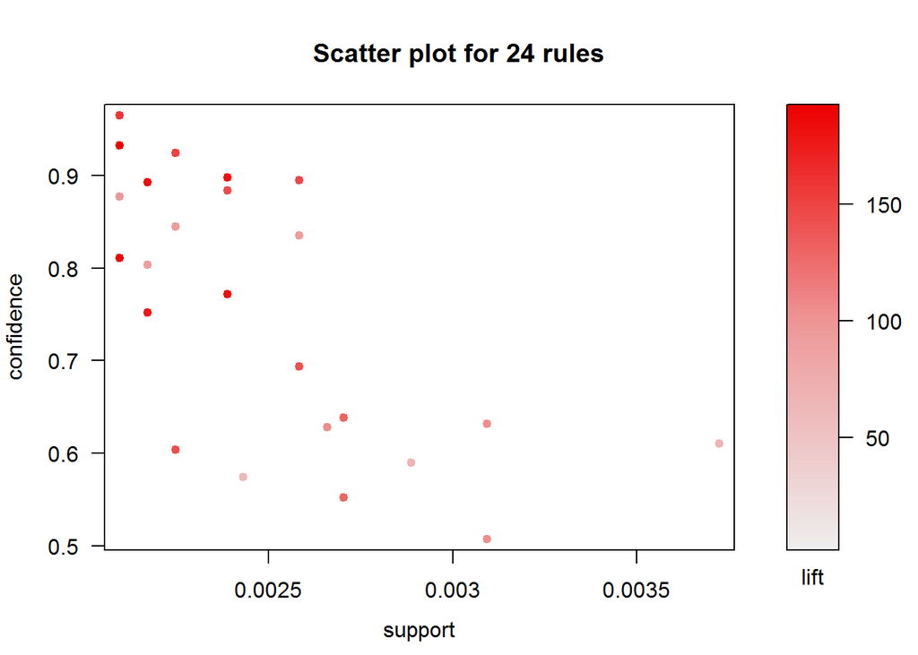

```r
library(arulesViz)
# plot to visualize
plot(bookotherrules)
```

### Other books analysis 2: Using following parameter settings

```r
#rm(bookotherrules)
bookotherrules2 <- apriori(bookbaskets, parameter = list(support =
                          0.001, confidence = 0.5, minlen = 1),
                          appearance = list(none = c(book_exclude_all),
                                            default="both")
                          )
```

```
## Apriori
##
## Parameter specification:
##  confidence minval smax arem  aval originalSupport maxtime support minlen
##         0.5    0.1    1 none FALSE            TRUE       5   0.001      1
##  maxlen target   ext
##      10  rules FALSE
##
## Algorithmic control:
##  filter tree heap memopt load sort verbose
##     0.1 TRUE TRUE  FALSE TRUE    2    TRUE
##
## Absolute minimum support count: 92
##
## set item appearances ...[50 item(s)] done [0.00s].
## set transactions ...[220447 item(s), 92108 transaction(s)] done [0.34s].
## sorting and recoding items ... [1090 item(s)] done [0.03s].
## creating transaction tree ... done [0.02s].
## checking subsets of size 1 2 3 4 5 done [0.02s].
## writing ... [198 rule(s)] done [0.00s].
## creating S4 object  ... done [0.02s].
```

### Strong Rules. Actionable Rules.

```r
#inspect(head(sort(bookotherrules, by = c("lift", "confidence"),10)))

bookotherrules2_sorted <- sort(bookotherrules2, by = c("lift", "confidence"))

inspect(head(bookotherrules2_sorted,10))
```

```
##      lhs                                       rhs                                        support confidence     lift
## [1]  {Soul Harvest: The World Takes Sides}  => {Apollyon: The Destroyer Is Unleashed} 0.001009684  0.7815126 580.5126
## [2]  {Apollyon: The Destroyer Is Unleashed} => {Soul Harvest: The World Takes Sides}  0.001009684  0.7500000 580.5126
## [3]  {Key of Knowledge}                     => {Key of Valor}                         0.001031398  0.7723577 564.6058
## [4]  {Key of Valor}                         => {Key of Knowledge}                     0.001031398  0.7539683 564.6058
## [5]  {Key of Knowledge}                     => {Key of Light}                         0.001074825  0.8048780 541.1365
## [6]  {Key of Light}                         => {Key of Knowledge}                     0.001074825  0.7226277 541.1365
## [7]  {Nicolae: The Rise of Antichrist}      => {Soul Harvest: The World Takes Sides}  0.001020541  0.6619718 512.3773
## [8]  {Soul Harvest: The World Takes Sides}  => {Nicolae: The Rise of Antichrist}      0.001020541  0.7899160 512.3773
## [9]  {Key of Valor}                         => {Key of Light}                         0.001009684  0.7380952 496.2371
## [10] {Key of Light}                         => {Key of Valor}                         0.001009684  0.6788321 496.2371
```

## Other Books Recommendation Results (2):

For example lhs rhs support confidence lift [1] {Soul Harvest: The World Takes Sides} => {Apollyon: The Destroyer Is Unleashed} 0.001009684 0.7815126 580.5126

a support value of 0.001 for this rule means the “Soul Harvest: The World Takes Sides” book appeared 0.1% of the bookbasket. A confidence of 0.78 for this rule implies that when “Soul Harvest: The World Takes Sides” book was purchased 78% of the time “Apollyon: The Destroyer Is Unleashed” book is also purchased. The lift of 580 measures “how much more likely an item is to be purchased relative to its typical purchase rate.

Similary rest of the above results can be explained.

**Based on this analysis displaying following book titles together would be very appealing to some sections of the book shop customers.**

- Soul Harvest: The World Takes Sides
- Apollyon: The Destroyer Is Unleashed
- Key of Knowledge
- Key of Valor
- Key of Light
- Nicolae: The Rise of Antichrist

### Write the rules out to a CSV file to provide to the store manager for future reference.

```r
# Other books results one
write(bookotherrules_sorted, file = "C:/Users/Jupiter/Downloads/RU/BIA6301ADM/Homework/submission/week4/ADM_Wekk4_Project/data/output/bookotherrules.csv",
      sep = ",", quote = TRUE, row.names = FALSE)

# Other books results two
write(bookotherrules2_sorted, file = "C:/Users/Jupiter/Downloads/RU/BIA6301ADM/Homework/submission/week4/ADM_Wekk4_Project/data/output/bookotherrules2.csv",
      sep = ",", quote = TRUE, row.names = FALSE)
```

### Recommendation to the store manager at Flourish and Blotts to increase sales and customer satisfaction.

- Design store display cases into four to five major sections, like “Best Selling Books”, “Book Club Members Area”, “Major Book Series”, “Customer Recommendations” and “Seasonal Books”. This provides clear layout and easy visibility and navigation to the customers and improve customer book browsing and buying experience.
- Based on the above analysis and recommendation stack above display cases with books preferred by each group of customers identified. This would increase additional book sales due to strategically placing additional books that customer would likely buy next to their preferred books or series.
- Add additional book types that are not currently sold at the book store, like text books to students, kids reading books and gift ideas. This will bring in new customer segment to the book store and increase sales.
- Provide customers with price comparison and matching facility to compete with online bookstores and to increase customer retention.